# R Notebook

http://rmarkdown.rstudio.com/r_notebooks.html

```r
array_1_1 <-array(1:50, dim=c(5,5,2))
array_1_1
```

```
, , 1

     [,1] [,2] [,3] [,4] [,5]
[1,]    1    6   11   16   21
[2,]    2    7   12   17   22
[3,]    3    8   13   18   23
[4,]    4    9   14   19   24
[5,]    5   10   15   20   25

, , 2

     [,1] [,2] [,3] [,4] [,5]
[1,]   26   31   36   41   46
[2,]   27   32   37   42   47
[3,]   28   33   38   43   48
[4,]   29   34   39   44   49
[5,]   30   35   40   45   50
```

Creating our very First Array

```r
array_1 <-array(1:36, dim=c(3,4,3))
array_1
```

```
, , 1

     [,1] [,2] [,3] [,4]
[1,]    1    4    7   10
[2,]    2    5    8   11
[3,]    3    6    9   12

, , 2

     [,1] [,2] [,3] [,4]
[1,]   13   16   19   22
[2,]   14   17   20   23
[3,]   15   18   21   24

, , 3

     [,1] [,2] [,3] [,4]
[1,]   25   28   31   34
[2,]   26   29   32   35
[3,]   27   30   33   36
```

DIM == “Integer vector of length one or more giving the maximal indices in each dimension.” Above we have ROWS or INDEX == 3 , COLUMNS == 4 and DIMENSIONS == 3 VALUES or OBSERVATIONS are filled in COLUMNS FIRST - ROWS NEXT

```r
is.array(df_1)
```

```
[1] FALSE
```

```r
array_2 <-array(1:24, dim=c(3,4))
array_2
```

```
     [,1] [,2] [,3] [,4]
[1,]    1    4    7   10
[2,]    2    5    8   11
[3,]    3    6    9   12
```

```r
class(array_2)
```

```
[1] "matrix"
```

```r
class(array_1)
```

```
[1] "array"
```

Both ARRAYS Stored as INTEGERS in Memory

WHAT ARE - VECTORS — One Dimension Arrays which can hold - NUMERIC , CHARACTER or LOGICAL DATA ## Float in Vector ?? # Vectors can be of THREE Types or MODES - which means the DATA TYPE they can hold.  
#  
A VECTOR is created using the - COMBINE Function()  
#  
Lets see an example of each type below -

```r
logical_vector <- c(TRUE,FALSE,TRUE,FALSE,FALSE,FALSE)
logical_vector
```

```
[1]  TRUE FALSE  TRUE FALSE FALSE FALSE
```

SCALARS - One Element Vectors - useful for holding CONSTANT values

```r
a1[2]
```

```
[1] NA
```

We refer ELEMENTS of a VECTOR by mentioning their INDEX - STARTING at 1

Take an example of the “num_vector” from above , we REFER the 1st ELEMENT - Element 1 as below , assign it to a VAR “nm_1” and then print the value stored within the VAR :-

```r
num_vector <- c(22.22,33,33,44)
class(num_vector)  ### Check -
```

```
[1] "numeric"
```

```r
nm_2 <- num_vector[2]
nm_3 <- num_vector[3]
nm_5 <- num_vector[5]
nm_2
```

[output not shown]

```r
nm_3
```

```
[1] 33
```

```r
nm_5
```

[output not shown]

We can also access a RANGE of elements by refering the INDEX of START and STOP Elements :-

```r
nm_range <- num_vector[2:5]
nm_range
```

[output not shown]

MATRICES ( Plural) MATRIX (Singular) - again like a VECTOR can store values in elements of the SAME MODE or SAME TYPE .

Matrices are TWO DIMENSIONAL ARRAYS of Data .

matrix(data = NA, nrow = 1, ncol = 1, byrow = FALSE, dimnames = NULL)

```r
m_1 <- matrix(data=66:90,nrow=2,ncol=2)
```

```
data length [25] is not a sub-multiple or multiple of the number of rows [2]
```

```r
m_1
```

```
     [,1] [,2]
[1,]   66   68
[2,]   67   69
```

Data set has been truncated as we didnt mention enough ROWS for the MATRIX , lets try again with 5 ROWS ….

```r
m_1 <- matrix(data=1:10,nrow=5,ncol=2)
m_1
```

```
     [,1] [,2]
[1,]    1    6
[2,]    2    7
[3,]    3    8
[4,]    4    9
[5,]    5   10
```

For Data Length 34 (data being numeric values from 66 to 99) , we need to provide a “multiple” or “sub-multiple”of 34 as the ROWS value - lets try with 17.

```r
m_1 <- matrix(data=66:99,nrow=17,ncol=2)
m_1
```

```
      [,1] [,2]
 [1,]   66   83
 [2,]   67   84
 [3,]   68   85
 [4,]   69   86
 [5,]   70   87
 [6,]   71   88
 [7,]   72   89
 [8,]   73   90
 [9,]   74   91
[10,]   75   92
[11,]   76   93
[12,]   77   94
[13,]   78   95
[14,]   79   96
[15,]   80   97
[16,]   81   98
[17,]   82   99
```

As seen above now the MATRIX - m_1 , can fit in the Data Values just fine with - 17 ROWS and 2 COLUMNS.

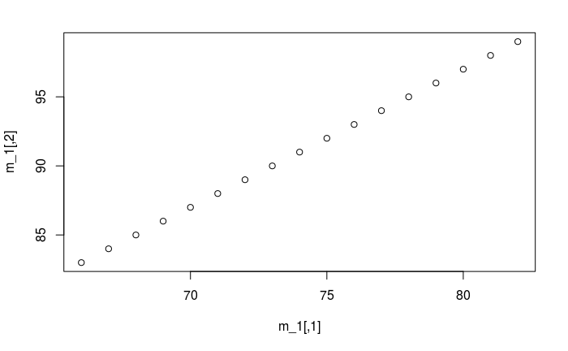

We can also reverse the ORDER of COLUMNS and ROWS

```r
m_1 <- matrix(data=66:99,nrow=2,ncol=17)
m_1
```

```
     [,1] [,2] [,3] [,4] [,5] [,6] [,7] [,8] [,9] [,10] [,11] [,12] [,13] [,14] [,15] [,16]
[1,]   66   68   70   72   74   76   78   80   82    84    86    88    90    92    94    96
[2,]   67   69   71   73   75   77   79   81   83    85    87    89    91    93    95    97
     [,17]
[1,]    98
[2,]    99
```

We still derive a MATRIX - m_1 , but the plot as seen below is illegible.

OR

Its extremely intelligent :)

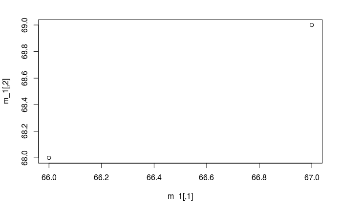

Weve seen the basic arguments for the Function “matrix()” above - now we look at “byrow” and “dimnames”.

DimNames or Dimension Names can be a LIST of structure - LIST(ROW_NAMES,COLUMN_NAMES) .

If we have only the 1st ELEMENT of a LIST then that defaults to ROW_NAMES and if we have a 2nd ELEMENT it defaults to COLUMN_NAMES.

Seen below - row_names and col_names created using the COMBINE - c() , function.

```r
m_1 <- matrix(data=66:69,nrow=2,ncol=2,byrow=FALSE,dimnames=list(row_names,col_names))
m_1
```

```
           Col_Name_1 Col_Name_2
Row_Name_1         66         68
Row_Name_2         67         69
```

As seen above when we dont specify ROW and COLUMN names we see a DIFFERENT Notation for default Columns and Rows Index values.

```
     [,1] [,2]
[1,]   66   68
[2,]   67   69
```

The ROWS are represented by INDEX of the kind – [1,] [2,]

The COLUMNS with – [,1] [,2]

Thus the MATRIX values, can also be accessed in this manner as seen below …

```
[1] 66
```

```
[1] 68
```

```
[1] 67
```

```
[1] 69
```

Weve seen examples of VECTORS and MATRICES in the above sections .

We have also seen ARRAYS which are again SINGLE MODE or TYPE but 3D or THREE DIMENSIONAL in shape .

In the section below we look at DATAFRAMES - which we probably end up using the most in our day to day analysis as they can hold MULTIPLE TYPES of DATA or are MULTIMODE in structure.

We shall import a .CSV File to begin with and create a DATAFRAME from the same

We also at a later stage look at creating own DataFrames from Manual inputs within R

?read.csv() ## Later – Look at read.table() in further detail.

read.csv(file, header = TRUE, sep = “,”, quote = “"”, dec = “.”, fill = TRUE, comment.char = “”, …)

| X. | Product.Name | Prod.ID | Date.of.Invoice | Date.of.Shipping | Cost.Price | Quantity | Sales.Price | Shipping.Index | Shipping.Type | Category |
| --- | --- | --- | --- | --- | --- | --- | --- | --- | --- | --- |
| 1 | OFF-LA-10002782 | MX-2014-143658 | 01-01-2013 | 02-01-2013 | 13.080 | 3 | 39.240 | 1 | PRIORITY | Office Supplies |
| 2 | FUR-FU-10004015 | MX-2012-155047 | 01-01-2013 | 02-01-2013 | 252.160 | 8 | 2017.280 | 2 | PRIORITY | Furniture |
| 3 | FUR-BO-10002352 | MX-2012-155047 | 01-01-2013 | 02-01-2013 | 193.280 | 2 | 386.560 | 3 | PRIORITY | Furniture |
| 4 | OFF-BI-10004428 | MX-2012-155047 | 01-01-2013 | 02-01-2013 | 35.440 | 4 | 141.760 | 4 | PRIORITY | Office Supplies |
| 5 | OFF-AR-10004594 | MX-2012-155047 | 01-01-2013 | 02-01-2013 | 71.600 | 2 | 143.200 | 5 | PRIORITY | Office Supplies |
| 6 | OFF-EN-10001375 | MX-2012-155047 | 01-01-2013 | 02-01-2013 | 56.120 | 2 | 112.240 | 6 | PRIORITY | Office Supplies |
| 7 | OFF-EN-10001375 | MX-2013-134096 | 01-01-2013 | 02-01-2013 | 56.120 | 2 | 112.240 | 7 | STANDARD | Office Supplies |
| 8 | TEC-MA-10004956 | MX-2013-134096 | 01-01-2013 | 02-01-2013 | 344.640 | 3 | 1033.920 | 8 | STANDARD | Technology |
| 9 | OFF-SU-10003474 | MX-2013-134096 | 01-01-2013 | 02-01-2013 | 97.360 | 4 | 389.440 | 9 | STANDARD | Office Supplies |
| 10 | TEC-AC-10001830 | MX-2013-134096 | 01-01-2013 | 02-01-2013 | 341.520 | 2 | 683.040 | 10 | STANDARD | Technology |

[output cut: 15 more lines]

As seen above there are various ways of reading in the Data from the .CSV format .

We used the read.csv() function which is present within the {utils} inbuilt package and is shipped along with - read.table() , read.csv2() , read.delim() and read.delim2()

We shall mostly be using - read.csv() and read.table()

Also as seen above – within the display of df_1 - the column names have the TYPE or MODE mentioned below - the “fctr” is the FACTOR , the “int” being the INTEGER etc .

Also this can be seen as such within the RIGHT PANEL of RSTudio in the ENVIRONEMENT >> Global Environment - section.

Kindly note that SCREENSHOTS of these can be seen within the GITHUB Repository Read Me file and path- “https://github.com/RohitDhankar/R-Beginners-Online-Virtual-Learning-Session/tree/master/Images_R_ScreenShots”

We need not mention the DEFAULTS and as seen below read.csv() - would work as well with just - the file path of the file.

| X. | Product.Name | Prod.ID | Date.of.Invoice | Date.of.Shipping | Cost.Price | Quantity | Sales.Price | Shipping.Index | Shipping.Type | Category |
| --- | --- | --- | --- | --- | --- | --- | --- | --- | --- | --- |
| 1 | OFF-LA-10002782 | MX-2014-143658 | 01-01-2013 | 02-01-2013 | 13.080 | 3 | 39.240 | 1 | PRIORITY | Office Supplies |
| 2 | FUR-FU-10004015 | MX-2012-155047 | 01-01-2013 | 02-01-2013 | 252.160 | 8 | 2017.280 | 2 | PRIORITY | Furniture |
| 3 | FUR-BO-10002352 | MX-2012-155047 | 01-01-2013 | 02-01-2013 | 193.280 | 2 | 386.560 | 3 | PRIORITY | Furniture |
| 4 | OFF-BI-10004428 | MX-2012-155047 | 01-01-2013 | 02-01-2013 | 35.440 | 4 | 141.760 | 4 | PRIORITY | Office Supplies |
| 5 | OFF-AR-10004594 | MX-2012-155047 | 01-01-2013 | 02-01-2013 | 71.600 | 2 | 143.200 | 5 | PRIORITY | Office Supplies |
| 6 | OFF-EN-10001375 | MX-2012-155047 | 01-01-2013 | 02-01-2013 | 56.120 | 2 | 112.240 | 6 | PRIORITY | Office Supplies |
| 7 | OFF-EN-10001375 | MX-2013-134096 | 01-01-2013 | 02-01-2013 | 56.120 | 2 | 112.240 | 7 | STANDARD | Office Supplies |
| 8 | TEC-MA-10004956 | MX-2013-134096 | 01-01-2013 | 02-01-2013 | 344.640 | 3 | 1033.920 | 8 | STANDARD | Technology |
| 9 | OFF-SU-10003474 | MX-2013-134096 | 01-01-2013 | 02-01-2013 | 97.360 | 4 | 389.440 | 9 | STANDARD | Office Supplies |
| 10 | TEC-AC-10001830 | MX-2013-134096 | 01-01-2013 | 02-01-2013 | 341.520 | 2 | 683.040 | 10 | STANDARD | Technology |

[output cut: 15 more lines]

To refer to the elements of a DATAFRAME we have the following options :-

| Date.of.Invoice |
| --- |
| 01-01-2013 |
| 01-01-2013 |
| 01-01-2013 |
| 01-01-2013 |
| 01-01-2013 |
| 01-01-2013 |
| 01-01-2013 |
| 01-01-2013 |
| 01-01-2013 |
| 01-01-2013 |

[output cut: 15 more lines]

df_2[c(“Category”,“Date.of.Invoice”)] Two COLUMNS or VARIABLES from df_2 assigned to create df_3 , using the COMBINE function.

| Category | Date.of.Invoice |
| --- | --- |
| Office Supplies | 01-01-2013 |
| Furniture | 01-01-2013 |
| Furniture | 01-01-2013 |
| Office Supplies | 01-01-2013 |
| Office Supplies | 01-01-2013 |
| Office Supplies | 01-01-2013 |
| Office Supplies | 01-01-2013 |
| Technology | 01-01-2013 |
| Office Supplies | 01-01-2013 |
| Technology | 01-01-2013 |

[output cut: 15 more lines]

Refer any COLUMN or VARIABLE of a DF using the DOLLAR Notation .

```r
df_4 <- df_3$Category
df_4
```

```
 [1] Office Supplies Furniture       Furniture       Office Supplies Office Supplies Office Supplies Office Supplies Technology      Office Supplies Technology
[11] Office Supplies Office Supplies Furniture       Office Supplies Office Supplies Office Supplies Office Supplies Furniture       Office Supplies Office Supplies
[21] Furniture       Technology      Office Supplies Office Supplies Office Supplies
Levels: Furniture Office Supplies Technology
```

```r
View(df_4)
```

A basic plot() of the DataFrame.

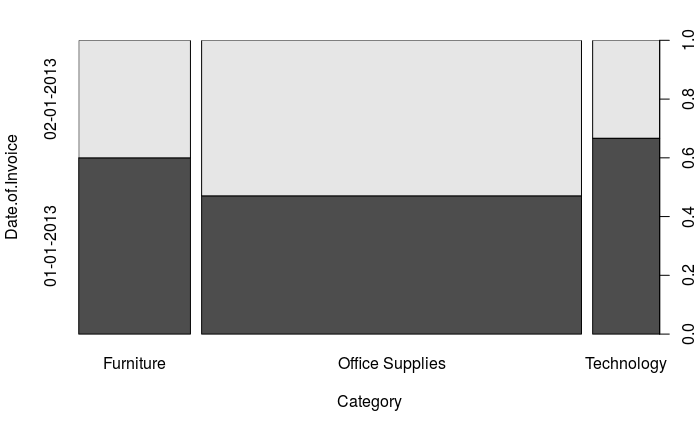

sessionInfo()

R version 3.3.2 (2016-10-31) Platform: x86_64-pc-linux-gnu (64-bit) Running under: Ubuntu 16.04.1 LTS

locale: [1] LC_CTYPE=en_IN.UTF-8 LC_NUMERIC=C LC_TIME=en_IN.UTF-8 LC_COLLATE=en_IN.UTF-8  
[5] LC_MONETARY=en_IN.UTF-8 LC_MESSAGES=en_IN.UTF-8 LC_PAPER=en_IN.UTF-8 LC_NAME=C  
[9] LC_ADDRESS=C LC_TELEPHONE=C LC_MEASUREMENT=en_IN.UTF-8 LC_IDENTIFICATION=C

attached base packages: [1] stats graphics grDevices utils datasets methods base

loaded via a namespace (and not attached): [1] backports_1.0.4 magrittr_1.5 rprojroot_1.1 htmltools_0.3.5 tools_3.3.2 base64enc_0.1-3 yaml_2.1.14  
[8] Rcpp_0.12.8 stringi_1.1.2 rmarkdown_1.3 knitr_1.15.1 jsonlite_1.1 stringr_1.1.0 digest_0.6.10  
[15] evaluate_0.10

EOF - R_Code.Rmd